# 28_match_graph_poly_eq

## 28_match_graph_poly_eq

#### Question

### Graph 1

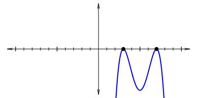

1. Which function matches Graph 1?
   - $A(x)~=~-(x-3)^{2}(x-7)^{2}$
   - $B(x)~=~-(x-3)^{2}(x+7)^{2}$
   - $C(x)~=~-(x+3)(x-7)^{2}$
   - $D(x)~=~(x+3)(x+7)^{2}$

### Graph 2

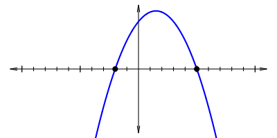

   Which function matches Graph 2?
   - $A(x)~=~(x-2)(x+5)$
   - $B(x)~=~(x-2)^{2}(x+5)$
   - $C(x)~=~-(x+2)(x-5)$
   - $D(x)~=~-(x+2)^{2}(x-5)^{2}$

### Graph 3

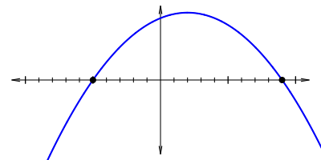

   Which function matches Graph 3?
   - $A(x)~=~-(x-5)(x+9)$
   - $B(x)~=~(x-5)^{2}(x+9)$
   - $C(x)~=~-(x+5)(x-9)$
   - $D(x)~=~(x+5)(x+9)$

#### Question

### Graph 1

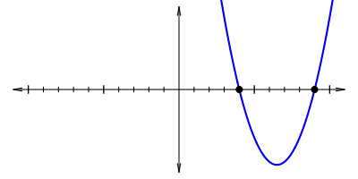

2. Which function matches Graph 1?
   - $A(x)~=~-(x-4)(x-9)$
   - $B(x)~=~(x-4)(x-9)$
   - $C(x)~=~(x-4)^{2}(x+9)^{2}$
   - $D(x)~=~-(x+4)^{2}(x-9)$

### Graph 2

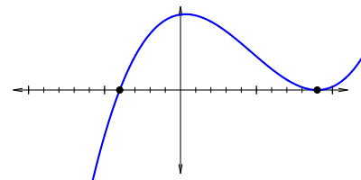

   Which function matches Graph 2?
   - $A(x)~=~(x-4)(x+9)^{2}$
   - $B(x)~=~(x+4)(x-9)^{2}$
   - $C(x)~=~-(x+4)^{2}(x-9)$
   - $D(x)~=~-(x+4)(x+9)^{2}$

### Graph 3

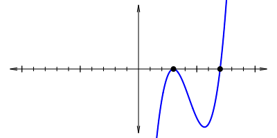

   Which function matches Graph 3?
   - $A(x)~=~(x-3)^{2}(x-7)$
   - $B(x)~=~-(x-3)^{2}(x-7)^{2}$
   - $C(x)~=~-(x-3)(x+7)^{2}$
   - $D(x)~=~-(x+3)(x+7)$

#### Question

### Graph 1

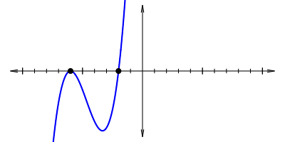

3. Which function matches Graph 1?
   - $A(x)~=~-(x-2)(x-6)$
   - $B(x)~=~(x-2)^{2}(x-6)$
   - $C(x)~=~(x-2)^{2}(x+6)$
   - $D(x)~=~(x+2)(x+6)^{2}$

### Graph 2

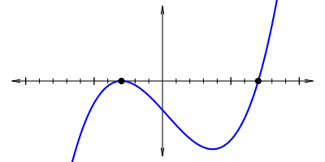

   Which function matches Graph 2?
   - $A(x)~=~(x-3)(x-7)^{2}$
   - $B(x)~=~-(x-3)^{2}(x+7)$
   - $C(x)~=~-(x+3)(x-7)$
   - $D(x)~=~(x+3)^{2}(x-7)$

### Graph 3

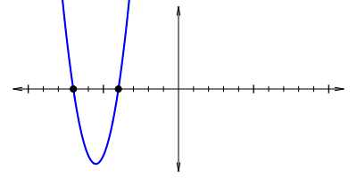

   Which function matches Graph 3?
   - $A(x)~=~-(x-4)^{2}(x+7)$
   - $B(x)~=~(x+4)(x+7)$
   - $C(x)~=~-(x+4)^{2}(x+7)$
   - $D(x)~=~(x+4)^{2}(x+7)$

#### Question

### Graph 1

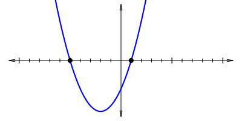

4. Which function matches Graph 1?
   - $A(x)~=~(x-1)^{2}(x-5)$
   - $B(x)~=~(x-1)(x+5)$
   - $C(x)~=~(x+1)(x-5)$
   - $D(x)~=~(x+1)^{2}(x-5)$

### Graph 2

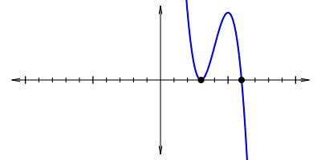

   Which function matches Graph 2?
   - $A(x)~=~-(x-3)^{2}(x-6)$
   - $B(x)~=~-(x+3)(x-6)$
   - $C(x)~=~-(x+3)(x-6)^{2}$
   - $D(x)~=~-(x+3)(x+6)^{2}$

### Graph 3

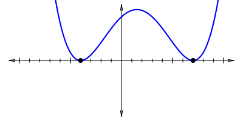

   Which function matches Graph 3?
   - $A(x)~=~(x-4)(x-7)$
   - $B(x)~=~-(x+4)(x-7)^{2}$
   - $C(x)~=~(x+4)^{2}(x-7)^{2}$
   - $D(x)~=~(x+4)^{2}(x+7)$

#### Question

### Graph 1

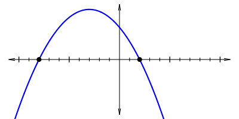

5. Which function matches Graph 1?
   - $A(x)~=~-(x-2)(x+8)$
   - $B(x)~=~-(x-2)^{2}(x+8)$
   - $C(x)~=~-(x+2)(x-8)$
   - $D(x)~=~(x+2)^{2}(x-8)$

### Graph 2

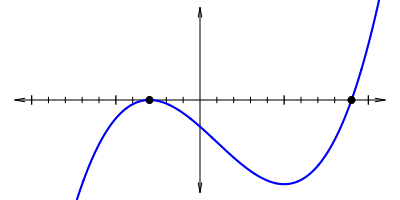

   Which function matches Graph 2?
   - $A(x)~=~-(x-3)(x-9)$
   - $B(x)~=~(x-3)^{2}(x+9)$
   - $C(x)~=~(x+3)^{2}(x-9)$
   - $D(x)~=~(x+3)^{2}(x+9)$

### Graph 3

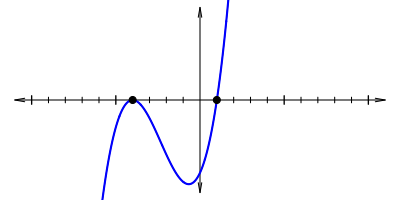

   Which function matches Graph 3?
   - $A(x)~=~-(x-1)^{2}(x-4)$
   - $B(x)~=~(x-1)(x+4)^{2}$
   - $C(x)~=~-(x-1)^{2}(x+4)^{2}$
   - $D(x)~=~(x+1)^{2}(x+4)$

#### Question

### Graph 1

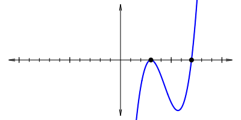

6. Which function matches Graph 1?
   - $A(x)~=~-(x-3)(x-7)^{2}$
   - $B(x)~=~(x-3)^{2}(x-7)$
   - $C(x)~=~-(x-3)^{2}(x+7)^{2}$
   - $D(x)~=~(x+3)(x-7)^{2}$

### Graph 2

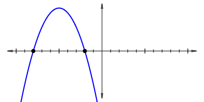

   Which function matches Graph 2?
   - $A(x)~=~-(x+2)(x-8)$
   - $B(x)~=~(x+2)(x-8)$
   - $C(x)~=~(x+2)^{2}(x-8)$
   - $D(x)~=~-(x+2)(x+8)$

### Graph 3

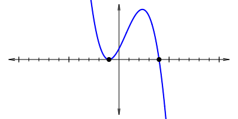

   Which function matches Graph 3?
   - $A(x)~=~-(x+1)(x-4)^{2}$
   - $B(x)~=~-(x+1)^{2}(x-4)$
   - $C(x)~=~(x+1)^{2}(x-4)$
   - $D(x)~=~-(x+1)(x+4)$

#### Question

### Graph 1

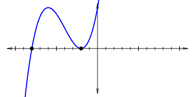

7. Which function matches Graph 1?
   - $A(x)~=~-(x-2)(x-8)$
   - $B(x)~=~-(x-2)^{2}(x-8)^{2}$
   - $C(x)~=~(x-2)(x+8)^{2}$
   - $D(x)~=~(x+2)^{2}(x+8)$

### Graph 2

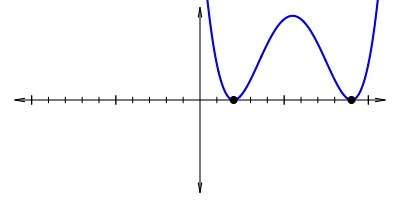

   Which function matches Graph 2?
   - $A(x)~=~(x-2)(x-9)$
   - $B(x)~=~(x-2)^{2}(x-9)^{2}$
   - $C(x)~=~(x+2)(x-9)$
   - $D(x)~=~(x+2)(x-9)^{2}$

### Graph 3

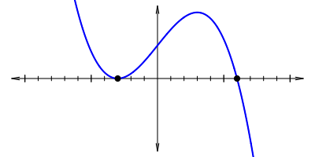

   Which function matches Graph 3?
   - $A(x)~=~-(x-3)(x+6)^{2}$
   - $B(x)~=~-(x-3)^{2}(x+6)$
   - $C(x)~=~-(x+3)(x-6)^{2}$
   - $D(x)~=~-(x+3)^{2}(x-6)$

#### Question

### Graph 1

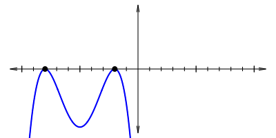

8. Which function matches Graph 1?
   - $A(x)~=~-(x-2)^{2}(x-8)$
   - $B(x)~=~-(x-2)^{2}(x+8)^{2}$
   - $C(x)~=~(x+2)(x-8)^{2}$
   - $D(x)~=~-(x+2)^{2}(x+8)^{2}$

### Graph 2

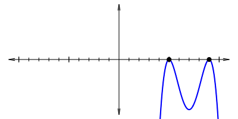

   Which function matches Graph 2?
   - $A(x)~=~-(x-5)^{2}(x-9)^{2}$
   - $B(x)~=~-(x-5)^{2}(x+9)$
   - $C(x)~=~-(x-5)^{2}(x+9)^{2}$
   - $D(x)~=~-(x+5)^{2}(x+9)^{2}$

### Graph 3

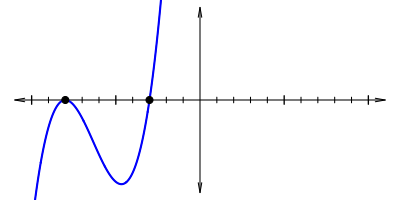

   Which function matches Graph 3?
   - $A(x)~=~(x-3)^{2}(x-8)$
   - $B(x)~=~-(x-3)(x+8)$
   - $C(x)~=~-(x+3)(x-8)$
   - $D(x)~=~(x+3)(x+8)^{2}$